# Forward eco-physiological modeling of $\delta O_{18}$ composition in Kauri tree rings

This IPython notebook accompanies the paper:

**Stable oxygen isotope signatures of early season wood in *agathis australis* (Kauri) tree-ring earlywood: Preliminary results and prospects for palaeoclimate reconstructions**

By *Andrew M. Lorrey, Tom H. Brookman, Michael N. Evans, Nicolas C. Fauchereau, Alison Criscitiello, Greg Eisheid, Anthony M. Fowler, Travis Horton and Daniel P. Schrag*

Submitted to *Journal of Geophysical Research - Atmosphere*, to be submitted.

Instructions regarding the installation of the necessary libraries and on how to run this notebook are provided in the **README.md** file, located in the main directory.

All code and data is available on github at:

https://github.com/nicolasfauchereau/model_isotope

- Define the parameter space of the model
- reads the inputs
- main loop
- prints the results
- figures
- diagnostics

### The line below makes sure the graphics are displayed inline in the notebook

```python
%matplotlib inline
```

### This import the required libraries (see instructions in the README.md file)

```python
import os
from math import exp
from itertools import product
import numpy as np
import pandas as pd
from matplotlib import pyplot as plt
```

```python
from statsmodels.formula.api import ols as OLS
```

### Defines the path where to find the csv files

```python
dpath = '../excel'
```

### Defines the path where to save the figures

```python
fpath = '../figures'
```

### Below is a small function to convert degrees Celsius to Kelvin

```python
def C2K(T):
    """
    conversion celsius to Kelvin
    """
    return T + 273.16
```

## STEP 1: Define the parameter space of the model

**Each parameter entering the calculations of $\delta 18_{O}$ can be defined as :**

Commented lines start with `#` (the keyboard shortcut `<ctrl-/>` (`<command-/>` on mac) toggles commented lines)

A brief description of each parameter is provided below:

```python
### ===========================================================================
### define the parameter space here
#gs_l = [0.25,]
gs_l = np.linspace(0.063,0.35,10)
leaf_width_l= [0.015,]
d_source_H2O_l = [-5.17,]
fract_through_stomata_l = [32,]
fract_through_boundary_layer_l = [28,]
# **eff_length** is the effective length at a minimum is double the average distance for a stoma to the central vein. For kauri, the avg distance is 0.0035m.
# Thus, the minimum for this variable is about 0.0077m.  Untested theory however suggests at least 2 orders of magnitude for the avg distance,
# so 0.35m
#eff_length_l = [0.0077,]
eff_length_l = np.linspace(0.0035,0.166,10)
C_l = [5.55e4,]
# #### Constants for calculations of $\Delta$ cellulose and $\Delta$ leaf
C_O_fract_l = [27,]
Dcel_Dom_l = [9,]
prop_exc_l = np.linspace(0.3,0.5,10)
#prop_exc_l = [0.45,]
prop_Xylem_l = [0.56,]
PAR_l = np.linspace(200,1000,10)
### ===========================================================================
```

### Reads the inputs (relative humidity, air temperature, pressure, windspeed) from the csv file

```python
inputs = pd.read_csv(os.path.join(dpath,'inputs.csv'), index_col = 0)
```

```python
inputs.head()
```

| Year | Rh | Air T | Pressure | windspeed |
| --- | --- | --- | --- | --- |
| 2009 | 84.40 | 14.27 | 1015.3 | 5.4 |
| 2008 | 79.80 | 14.63 | 1018.3 | 5.3 |
| 2007 | 78.40 | 14.43 | 1017.1 | 4.9 |
| 2006 | 81.25 | 14.80 | 1018.7 | 5.4 |
| 2005 | 81.30 | 15.07 | 1016.2 | 4.9 |

### Reads the `observed` values of $\delta 18_{0}$

```python
obs = pd.read_csv(os.path.join(dpath,'observed_tree_rings.csv'), index_col=0)
```

### Multiply by the standard deviation and add the mean to get the $\delta 18_{O}$ values

```python
obs['raw'] = (obs['av']*1.73) + 31.82
```

### Generate the parameter space

```python
parameter_space = product(gs_l,leaf_width_l,d_source_H2O_l,fract_through_stomata_l,fract_through_boundary_layer_l,\
                          eff_length_l,C_l,C_O_fract_l,Dcel_Dom_l,prop_exc_l,prop_Xylem_l, PAR_l)

parameter_space = list(parameter_space)
```

### Below the main loops (over inputs and over parameter space) are implemented: *Do not* modify anything here

```python
### ===========================================================================

l = []

for index in xrange(len(inputs)):

    ### ===========================================================================
    ### loops over the inputs
    rh, airtemp, pressure, windspeed = inputs.irow(index)

    param_outputs= []

    ### ===========================================================================
    ### start the loop over the parameter space
    for parameters in parameter_space:
        gs,leaf_width,d_source_H2O,fract_through_stomata,fract_through_boundary_layer,\
        eff_length,C,C_O_fract,Dcel_Dom,prop_exc,prop_Xylem, PAR = parameters

        ### ===========================================================================
        ### Energy balance calculations
        rs = 1. / gs

        r_times_b = 3.8 * (leaf_width**0.25)*(windspeed**(-0.5))

        rb = 0.89 * r_times_b

        gr = (4*0.98*(0.000000056703)*(C2K(airtemp)**3))/(29.2)

        rBH = 1./((1./r_times_b)+gr)

        Qtot = (PAR/4.6)*2

        Qabs = 0.5 * Qtot

        ### ===========================================================================
        ### Calculating $\epsilon$

        lesstemp = airtemp - 1.

        estemp = (6.13753 * exp(lesstemp * ((18.564 - (lesstemp/254.4)))/(lesstemp +255.57)))*100

        lesstemp_K = C2K(lesstemp)

        s = (((6.13753 * exp(airtemp * ((18.564 - (airtemp/254.4)))/(airtemp +255.57))))-estemp)\
        /(C2K(airtemp)-C2K(lesstemp))

        smbar = 6.13753*(((airtemp+255.7)*(18.564 - (2*airtemp/254.4)) - airtemp*(18.564 - \
                            (airtemp/254.4)))/((airtemp+255.57)**2))*(exp(airtemp*(18.564 - \
                                                        (airtemp/254.4))/(airtemp + 255.57)))

        epsilon = (smbar*44012)/(29.2*(pressure))

        ### ===========================================================================
        ### Calculating $\frac{EA}{EI}$

        ea = (rh / 100) * (6.13753 * exp(airtemp * ((18.564 - (airtemp/254.4)))/(airtemp +255.57)))

        es = (6.13753 * exp(airtemp * ((18.564 - (airtemp/254.4)))/(airtemp +255.57)))

        D = (((6.13753 * exp(airtemp * ((18.564 - (airtemp/254.4)))\
                             /(airtemp +255.57))))-ea)/pressure

        temp_diff = (rBH*((Qabs*(rs+rb))-(44012*D)))/(29.2*(rs+rb+(epsilon*rBH)))

        leaf_temp = airtemp + temp_diff

        ei = (6.13753 * exp(leaf_temp * ((18.564 - (leaf_temp/254.4)))\
                            /(leaf_temp +255.57)))

        leaf_temp_K = C2K(leaf_temp)

        ea_ei = ea / ei

        ### ===========================================================================
        ### Calculating transpiration

        transpiration = (epsilon * rBH * Qabs / 44012. + D) \
        / (rs + rb + epsilon * rBH)

        ### ===========================================================================
        ### Craig & Gordon parameters

        d_water_vapour = d_source_H2O + -1*(2.644-3.206*(1000/C2K(airtemp))+\
                                            1.534*(1e6/(C2K(airtemp)*C2K(airtemp))))

        ek = ((fract_through_stomata*1/gs)+(fract_through_boundary_layer*rb))/((1/gs)+rb)

        e_star = 2.644-3.206*((1e3)/leaf_temp_K)+1.534*((10**6)/(leaf_temp_K**2))

        dv = ((d_water_vapour/1e3)*(1+(d_source_H2O/1e3))+(d_source_H2O/1e3))*1e3

        dv = ((d_water_vapour/1e3)*(1+(d_source_H2O/1e3))+(d_source_H2O/1e3))*1e3

        de = ek+e_star+((d_water_vapour-ek)*ea_ei)

        ### ===========================================================================
        ### Estimating the Peclet effect

        D_Peclet = 0.000000119*(exp(-(637/(leaf_temp_K-137))))

        p_Peclet = (transpiration*eff_length)/(C*D_Peclet)

        DL = (de*(1-exp(-1*p_Peclet)))/p_Peclet

        dL = ((DL/1e3)*(1+(d_source_H2O/1e3))+(d_source_H2O/1e3))*1e3

        ### ===========================================================================
        ### Calculating $\Delta$ cellulose and $\Delta$ leaf

        D_sucrose = DL + C_O_fract

        D_cellulose = (DL*(1-(prop_exc*prop_Xylem)))+C_O_fract # only place where prop_ex appears

        D_leaf = D_cellulose - Dcel_Dom

        d_sucrose = ((D_sucrose/1e3)*(1+(d_source_H2O/1e3))+(d_source_H2O/1e3))*1e3

        d_leaf = ((D_leaf/1e3)*(1+(d_source_H2O/1e3))+(d_source_H2O/1000))*1e3

        ### ===========================================================================
        ### OUTPUT = $\Delta O_{18}$ in tree-rings cellulose

        OUTPUT = ((D_cellulose/1e3)*(1+(d_source_H2O/1e3))+(d_source_H2O/1e3))*1e3

        param_outputs.append(OUTPUT)

    l.append(param_outputs)

l = np.array(l)
```

```python
mean_l = l.mean(0)

std_l = l.std(0)

l_s = (l - mean_l) / std_l
```

### Calculate correlation coefficients and find the maximum

```python
R_coeff = []
for i in np.arange(l_s.shape[1]):
    R_coeff.append(np.corrcoef(l_s[:,i], obs['av'].values.flatten())[0,1])
R_coeff = np.array(R_coeff)
maxR = np.argmax(R_coeff)
```

```python
### ===========================================================================
RMSE = []
for i in np.arange(l.shape[1]):
    RMSE.append(np.sqrt((obs['raw'] - l[:,i])**2).mean())
RMSE = np.array(RMSE)
minRMSE = np.argmin(RMSE)
```

### Find the corresponding parameters in the parameter space

```python
#parameter_space = np.array(parameter_space)

optimal_params_R = parameter_space[maxR]
optimal_params_RMSE = parameter_space[minRMSE]
```

### Print the results: best set of parameters that respectively minimize (maximize) the RMSE (Pearson's R)

```python
results = """
The Maximum R value ({0:<4.2f}) is obtained for:
gs = {1[0]:<5.2f}
leaf_width = {1[1]:<6.4f}
d_source_H2O = {1[2]:<5.2f}
fract_through_stomata = {1[3]:<5.2f}
fract_through_boundary_layer = {1[4]:<5.2f}
eff_length = {1[5]:<6.4f}
C = {1[6]:<5.2f}
C_O_fract = {1[7]:<5.2f}
Dcel_Dom = {1[8]:<5.2f}
prop_exc = {1[9]:<5.2f}
prop_Xylem = {1[10]:<5.2f}
PAR = {1[11]:<5.2f}

The corresponding RMSE. is = {2:<5.2f} (max: {3:<5.2f})
""".format(R_coeff[maxR],optimal_params_R,RMSE[maxR],RMSE.max())

print(results)
```

```
The Maximum R value (0.72) is obtained for:
gs = 0.35
leaf_width = 0.0150
d_source_H2O = -5.17
fract_through_stomata = 32.00
fract_through_boundary_layer = 28.00
eff_length = 0.0577
C = 55500.00
C_O_fract = 27.00
Dcel_Dom = 9.00
prop_exc = 0.30
prop_Xylem = 0.56
PAR = 200.00

The corresponding RMSE. is = 7.52  (max: 8.71 )
```

```python
results = """
The Minimum RMSE value ({0:<4.2f}) is obtained for:
gs = {1[0]:<5.2f}
leaf_width = {1[1]:<6.4f}
d_source_H2O = {1[2]:<5.2f}
fract_through_stomata = {1[3]:<5.2f}
fract_through_boundary_layer = {1[4]:<5.2f}
eff_length = {1[5]:<6.4f}
C = {1[6]:<5.2f}
C_O_fract = {1[7]:<5.2f}
Dcel_Dom = {1[8]:<5.2f}
prop_exc = {1[9]:<5.2f}
prop_Xylem = {1[10]:<5.2f}
PAR = {1[11]:<5.2f}

The corresponding R. coeff. is = {2:<5.2f} (min: {3:<5.2f})

""".format(RMSE[minRMSE],optimal_params_RMSE,R_coeff[minRMSE],R_coeff.min())

print(results)
```

```
The Minimum RMSE value (0.82) is obtained for:
gs = 0.06
leaf_width = 0.0150
d_source_H2O = -5.17
fract_through_stomata = 32.00
fract_through_boundary_layer = 28.00
eff_length = 0.0035
C = 55500.00
C_O_fract = 27.00
Dcel_Dom = 9.00
prop_exc = 0.30
prop_Xylem = 0.56
PAR = 1000.00

The corresponding R. coeff. is = 0.58  (min: 0.58 )
```

### Creates the figures

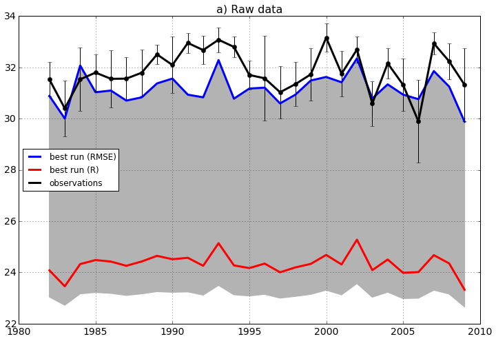

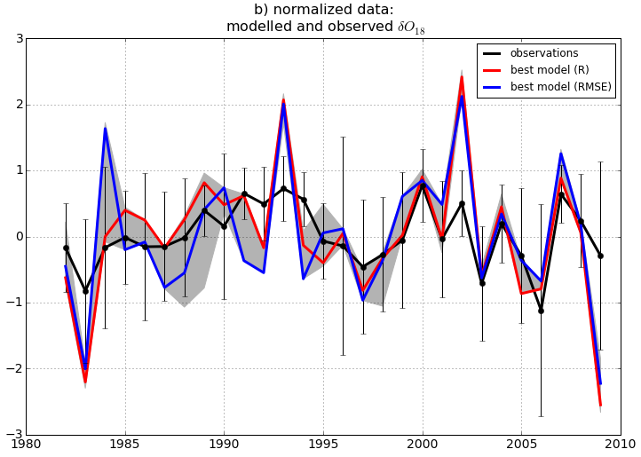

```python
### ===========================================================================
### raw modelled values (possibly P-dimensional)
f, ax = plt.subplots(figsize=(12,8))
#ax.plot(inputs.index, l, color='coral', lw=1.5, zorder=2)
ax.fill_between(inputs.index, l.min(1),l.max(1), color='0.7', lw=1.5, zorder=2)
ax.plot(inputs.index, l[:,minRMSE], color='b', lw=3, label='best run (RMSE)')
ax.plot(inputs.index, l[:,maxR], color='r', lw=3, label='best run (R)')
ax.plot(obs.index, obs['raw'].values, color='k', lw=3, label='observations')
ax.errorbar(obs.index, obs['raw'].values, yerr=obs['std'].values, fmt='o', color='k')
ax.set_title('a) Raw data', fontsize=16)
[x.set_fontsize(14) for x in ax.yaxis.get_ticklabels()]
[x.set_fontsize(14) for x in ax.xaxis.get_ticklabels()]
ax.legend(loc=0)
ax.grid('on')
f.savefig(os.path.join(fpath,'raw_modelled_delta18O.png'), bbox_inches='tight', dpi=200)
plt.show()

### ===========================================================================
### normalized modelled values (possibly P-dimensional) and observed values
f, ax = plt.subplots(figsize=(12,8))
#ax.plot(inputs.index, l_s, color='coral', lw=1.5)
ax.fill_between(inputs.index, l_s.min(1),l_s.max(1), color='0.7', zorder=2)
ax.plot(obs.index, obs['av'].values, color='k', lw=3, label='observations')
ax.plot(inputs.index, l_s[:,maxR], color='r', lw=3, label='best model (R)')
ax.plot(inputs.index, l_s[:,minRMSE], color='b', lw=3, label='best model (RMSE)')
ax.errorbar(obs.index, obs['av'].values, yerr=obs['std'].values, fmt='o', color='k')
ax.legend(loc=0)
[x.set_fontsize(14) for x in ax.yaxis.get_ticklabels()]
[x.set_fontsize(14) for x in ax.xaxis.get_ticklabels()]

ax.set_title('b) normalized data:\n modelled and observed $\delta O_{18}$', fontsize=16)
#ax.text(2006,2.5,'R=%4.2f' % (np.corrcoef(l_s.flatten(),obs['av'].values)[0,1]))
ax.grid('on')
f.savefig(os.path.join(fpath,'normalized_modelled_delta18O.png'), bbox_inches='tight', dpi=200)
plt.show()
```

```python
caption="""
a) The black curve represents the observation along with the error bars (Delta O18, permille). The Solid blue curve is
the best model, optimized over the parameter space for minimizing the Root Mean Squared Error (RMSE) between the modelled
and observed time-series. The solid red curve is the best model, optimized over the parameter space for maximizing the
Pearson's correlation coefficient between the modelled andobserved time-series.

The range between the minimum and maximum values of the modelled time-series for each time-step is shaded in gray.

b) same as in a but normalized time-series are displayed, error bars in standard deviation units"""

print(caption)
```

```
a) The black curve represents the observation along with the error bars (Delta O18, permille). The Solid blue curve is
the best model, optimized over the parameter space for minimizing the Root Mean Squared Error (RMSE) between the modelled
and observed time-series. The solid red curve is the best model, optimized over the parameter space for maximizing the
Pearson's correlation coefficient between the modelled andobserved time-series.

The range between the minimum and maximum values of the modelled time-series for each time-step is shaded in gray.

b) same as in a but normalized time-series are displayed, error bars in standard deviation units
```

## Diagnostics

```python
results  = pd.DataFrame(np.c_[l[:,maxR], l[:,minRMSE], obs['av'].values], index=inputs.index, \
                        columns = ['maxR', 'minRMSE','obs'])
```

### correlation matrix

```python
results.corr()
```

|  | maxR | minRMSE | obs |
| --- | --- | --- | --- |
| maxR | 1.000000 | 0.869394 | 0.722915 |
| minRMSE | 0.869394 | 1.000000 | 0.577339 |
| obs | 0.722915 | 0.577339 | 1.000000 |

### Observations versus results optimised for R (maximise Pearson's R)

```python
max_R_mod = OLS('obs ~ maxR', results).fit()
```

```python
max_R_mod.summary()
```

OLS Regression Results

| Dep. Variable: | obs | R-squared: | 0.523 |
| --- | --- | --- | --- |
| Model: | OLS | Adj. R-squared: | 0.504 |
| Method: | Least Squares | F-statistic: | 28.46 |
| Date: | Fri, 05 Sep 2014 | Prob (F-statistic): | 1.39e-05 |
| Time: | 09:53:41 | Log-Likelihood: | -7.9786 |
| No. Observations: | 28 | AIC: | 19.96 |
| Df Residuals: | 26 | BIC: | 22.62 |
| Df Model: | 1 |  |  |

|  | coef | std err | t | P>\|t\| | [95.0% Conf. Int.] |
| --- | --- | --- | --- | --- | --- |
| Intercept | -20.7895 | 3.900 | -5.330 | 0.000 | -28.806 -12.773 |
| maxR | 0.8553 | 0.160 | 5.335 | 0.000 | 0.526 1.185 |

| Omnibus: | 1.295 | Durbin-Watson: | 1.566 |
| --- | --- | --- | --- |
| Prob(Omnibus): | 0.523 | Jarque-Bera (JB): | 0.352 |
| Skew: | -0.128 | Prob(JB): | 0.839 |
| Kurtosis: | 3.486 | Cond. No. | 1.51e+03 |

### Observations versus results optimised for RMSE (minimise RMSE)

```python
min_RMSE_mod = OLS('obs ~ minRMSE', results).fit()
```

```python
min_RMSE_mod.summary()
```

OLS Regression Results

| Dep. Variable: | obs | R-squared: | 0.333 |
| --- | --- | --- | --- |
| Model: | OLS | Adj. R-squared: | 0.308 |
| Method: | Least Squares | F-statistic: | 13.00 |
| Date: | Fri, 05 Sep 2014 | Prob (F-statistic): | 0.00130 |
| Time: | 09:54:07 | Log-Likelihood: | -12.654 |
| No. Observations: | 28 | AIC: | 29.31 |
| Df Residuals: | 26 | BIC: | 31.97 |
| Df Model: | 1 |  |  |

|  | coef | std err | t | P>\|t\| | [95.0% Conf. Int.] |
| --- | --- | --- | --- | --- | --- |
| Intercept | -14.7194 | 4.087 | -3.601 | 0.001 | -23.121 -6.318 |
| minRMSE | 0.4731 | 0.131 | 3.605 | 0.001 | 0.203 0.743 |

| Omnibus: | 0.729 | Durbin-Watson: | 1.622 |
| --- | --- | --- | --- |
| Prob(Omnibus): | 0.695 | Jarque-Bera (JB): | 0.092 |
| Skew: | -0.063 | Prob(JB): | 0.955 |
| Kurtosis: | 3.251 | Cond. No. | 1.71e+03 |